# Databases - Case

## Problem

EarthX is a research instutition that studies all things related to climate. They are currently studying hydrology patterns across a river with 21 river channels, numbered 1 to 21, to understand how climate change is impacting the river. They would like to focus on River Channel 1 and compare its water cycle pattern to the river's primary watershed. River Channel 1 is the furthest from the watershed out of all the channels. EarthX would like to focus on information starting in 1990, when it was first reported that the planet had warmed by 0.5 degrees Celsius within the prior century.

Some terminology:

- PREC and PRECIP refers to precipitation
- PET refers to potential evapotranspiration which is the amount of evaporation that would occur given a sufficient water source
- A watershed is a basin where precipitation collects and drains into a river
- RCH revers to River Channel
- mm is milimeters

EarthX has provided a SQLite database and asked you to do a preliminary analysis and come up with a proposal for a project.

In this case, you will learn how to:

- Query data from SQL
- Do basic data analysis
- Formulate a proposal

## Step 1: Connect to Database

```python
import sqlite3
import pandas as pd
import numpy as np
import matplotlib.pyplot as plt
%matplotlib inline
# Create the connection
cnx = sqlite3.connect(r'data/demo.db3')
```

## Step 2: Check All Tables in Database

```python
# create the dataframe from a query
df = pd.read_sql_query("SELECT name FROM sqlite_master WHERE type='table'", cnx)
```

```python
df
```

|  | name |
| --- | --- |
| 0 | rch |
| 1 | hru |
| 2 | sub |
| 3 | sed |
| 4 | watershed_daily |
| 5 | watershed_monthly |
| 6 | watershed_yearly |
| 7 | channel_dimension |
| 8 | hru_info |
| 9 | sub_info |
| 10 | rch_info |
| 11 | ave_plant |
| 12 | ave_annual_hru |
| 13 | ave_monthly_basin |
| 14 | ave_annual_basin |
| 15 | sqlite_sequence |
| 16 | watershed_yearly_bk |
| 17 | Temperature |

We can see there is a table containing RCH info and a table containing WATERSHED INFO in different intervals. Let's take a look if RCH has time series data:

```python
pd.read_sql_query("SELECT * FROM RCH LIMIT 3", cnx)
```

|  | RCH | YR | MO | FLOW_INcms | FLOW_OUTcms | EVAPcms | TLOSScms | SED_INtons | SED_OUTtons | SEDCONCmg_kg | ... | BED_PSTmg | BACTP_OUTct | BACTLP_OUTct | CMETAL_1kg | CMETAL_2kg | CMETAL_3kg | TOT_Nkg | TOT_Pkg | NO3ConcMg_l | WTMPdegc |
| --- | --- | --- | --- | --- | --- | --- | --- | --- | --- | --- | --- | --- | --- | --- | --- | --- | --- | --- | --- | --- | --- |
| 0 | 1 | 1981 | 1 | 146.343765 | 146.252487 | 0.091281 | 0.0 | 2.332046e-07 | 6.161946e+04 | 1.553719e+02 | ... | 0.0 | 0.0 | 0.0 | 0.0 | 0.0 | 0.0 | 806.015747 | 0.000000 | 0.0 | 0.0 |
| 1 | 2 | 1981 | 1 | 96.225693 | 96.182854 | 0.042821 | 0.0 | 1.642676e-07 | 0.000000e+00 | 0.000000e+00 | ... | 0.0 | 0.0 | 0.0 | 0.0 | 0.0 | 0.0 | 442.463013 | 0.000000 | 0.0 | 0.0 |
| 2 | 3 | 1981 | 1 | 11.952719 | 11.861368 | 0.091352 | 0.0 | 2.032582e-07 | 2.032582e-07 | 6.595061e-09 | ... | 0.0 | 0.0 | 0.0 | 0.0 | 0.0 | 0.0 | 110.399124 | 0.009118 | 0.0 | 0.0 |

3 rows × 49 columns

Both Year and Month are checked, so we can use either of those. Since months can be grouped into years but years cannot be broken down into months with further information, let's work with months to allow ourselves more flexibility.

## Step 3: Get Monthy Watershed Data

```python
watershed_data = pd.read_sql_query("SELECT * From watershed_monthly", cnx)
```

```python
watershed_data
```

|  | YR | MO | PREC_mm | SURQ_mm | LATQ_mm | GWQ_mm | PERCOLA_mm | TILEQ_mm | SW_mm | ET_mm | ... | WYLD_mm | SYLD_tons | NO3_SURQ | NO3_LATQ | NO3_PERC | NO3_CROP | N_ORG | P_SOL | P_ORG | TILENO3 |
| --- | --- | --- | --- | --- | --- | --- | --- | --- | --- | --- | --- | --- | --- | --- | --- | --- | --- | --- | --- | --- | --- |
| 0 | 1981 | 1 | 96.290161 | 5.159814e-01 | 0.412547 | 6.688114 | 19.906706 | 0.0 | 1854.224243 | 6.871742 | ... | 8.681976 | 1.793347e-01 | 2.173997e-04 | 0.002270 | 1.310477 | 0.000000 | 1.262282e-01 | 1.126891e-04 | 1.540681e-02 | 0.0 |
| 1 | 1981 | 2 | 160.228043 | 3.346802e+00 | 0.645279 | 9.148776 | 34.368122 | 0.0 | 1766.253052 | 9.165532 | ... | 13.862185 | 1.212717e+00 | 6.267096e-04 | 0.001956 | 1.174126 | 0.000000 | 8.965996e-01 | 5.604379e-04 | 1.100000e-01 | 0.0 |
| 2 | 1981 | 3 | 136.652908 | 3.824994e+00 | 1.481317 | 18.518496 | 34.367245 | 0.0 | 1990.753540 | 13.520476 | ... | 25.018511 | 1.262960e+00 | 8.495682e-04 | 0.007549 | 0.504497 | 0.000000 | 6.799346e-01 | 5.445935e-04 | 8.338834e-02 | 0.0 |
| 3 | 1981 | 4 | 118.857407 | 5.457377e+00 | 4.583438 | 24.400629 | 49.048290 | 0.0 | 2067.317871 | 19.293779 | ... | 35.487270 | 4.470516e+00 | 3.027024e-03 | 0.015503 | 0.896418 | 0.094205 | 1.208029e+00 | 6.110753e-04 | 1.482405e-01 | 0.0 |
| 4 | 1981 | 5 | 84.546982 | 7.327817e+01 | 19.727270 | 50.328770 | 179.912231 | 0.0 | 2423.156494 | 42.863754 | ... | 144.976639 | 5.197903e+01 | 2.803491e-02 | 0.021348 | 1.192984 | 4.446020 | 6.346692e+00 | 3.033973e-03 | 7.859770e-01 | 0.0 |
| 5 | 1981 | 6 | 44.837185 | 4.562505e+00 | 5.240129 | 73.161331 | 25.839384 | 0.0 | 1758.018311 | 46.390720 | ... | 84.575081 | 2.622470e+00 | 6.912132e-05 | 0.004642 | 0.215444 | 2.140753 | 5.109928e-01 | 3.598040e-04 | 6.258814e-02 | 0.0 |
| 6 | 1981 | 7 | 32.325985 | 3.925863e+01 | 14.054975 | 71.430473 | 82.685196 | 0.0 | 1261.352417 | 33.217556 | ... | 128.423569 | 2.931638e+01 | 6.832188e-06 | 0.005688 | 0.120292 | 0.186843 | 2.081491e+00 | 2.973753e-03 | 2.549605e-01 | 0.0 |
| 7 | 1981 | 8 | 20.651497 | 4.672448e-02 | 2.434076 | 62.404942 | 5.539300 | 0.0 | 967.230591 | 20.251663 | ... | 67.842125 | 2.213612e-02 | 7.741595e-08 | 0.001549 | 0.019980 | 0.432098 | 3.959963e-04 | 3.584700e-06 | 4.858828e-05 | 0.0 |
| 8 | 1981 | 9 | 16.579657 | 1.106777e-04 | 1.186191 | 41.641441 | 4.233130 | 0.0 | 874.320618 | 15.243327 | ... | 45.412102 | 3.691889e-05 | 2.016745e-08 | 0.001029 | 0.018158 | 0.039997 | 1.450089e-05 | 3.571221e-08 | 1.790821e-06 | 0.0 |
| 9 | 1981 | 10 | 59.672932 | 0.000000e+00 | 0.742090 | 26.393599 | 0.470224 | 0.0 | 1057.720703 | 9.915999 | ... | 29.387749 | 4.947615e-13 | 1.683587e-08 | 0.000907 | 0.006713 | 0.000000 | 1.723009e-08 | 1.683587e-08 | 1.684981e-08 | 0.0 |
| 10 | 1981 | 11 | 52.785095 | 1.659896e-02 | 0.571388 | 13.759267 | 3.179891 | 0.0 | 1244.743042 | 10.940271 | ... | 16.105352 | 3.245843e-03 | 1.989055e-05 | 0.001027 | 0.043516 | 0.000000 | 2.092114e-03 | 5.613669e-06 | 2.961821e-04 | 0.0 |
| 11 | 1981 | 12 | 72.177277 | 4.957117e-02 | 0.255700 | 8.198129 | 3.648742 | 0.0 | 1554.616577 | 9.308161 | ... | 9.934283 | 1.143287e-02 | 8.529927e-05 | 0.000707 | 0.113284 | 0.000000 | 4.996725e-03 | 1.504464e-05 | 7.632716e-04 | 0.0 |
| 12 | 1982 | 1 | 59.744789 | 6.443456e-01 | 0.236845 | 5.157058 | 7.381819 | 0.0 | 1719.712769 | 6.180325 | ... | 7.032940 | 1.952684e-01 | 1.789847e-04 | 0.000864 | 0.285757 | 0.000000 | 1.118840e-01 | 1.104189e-04 | 1.487312e-02 | 0.0 |
| 13 | 1982 | 2 | 87.514702 | 1.443130e-01 | 0.390213 | 5.734013 | 17.743359 | 0.0 | 1674.580078 | 8.613997 | ... | 7.241701 | 3.231490e-02 | 1.178400e-04 | 0.001369 | 0.654359 | 0.000000 | 3.161804e-02 | 4.727484e-05 | 4.194429e-03 | 0.0 |
| 14 | 1982 | 3 | 150.992188 | 2.060904e+00 | 0.577165 | 10.389558 | 27.333090 | 0.0 | 1873.978882 | 13.235467 | ... | 13.867465 | 4.280545e-01 | 1.411706e-03 | 0.001922 | 0.779044 | 0.000000 | 3.047374e-01 | 4.564435e-04 | 3.985112e-02 | 0.0 |
| 15 | 1982 | 4 | 97.741066 | 2.680382e+01 | 11.865144 | 20.628792 | 106.552345 | 0.0 | 2065.758057 | 27.511183 | ... | 59.953560 | 2.082467e+01 | 1.356902e-03 | 0.020140 | 0.972918 | 0.082126 | 3.970570e+00 | 1.374096e-03 | 4.922565e-01 | 0.0 |
| 16 | 1982 | 5 | 87.788002 | 2.588316e+01 | 10.564350 | 47.014141 | 90.632217 | 0.0 | 2226.698975 | 40.409225 | ... | 84.892868 | 1.933811e+01 | 4.384045e-03 | 0.008696 | 0.597715 | 5.468311 | 3.575064e+00 | 2.076362e-03 | 4.378524e-01 | 0.0 |
| 17 | 1982 | 6 | 62.786430 | 7.671919e+00 | 7.241755 | 58.936886 | 51.900253 | 0.0 | 1700.419800 | 50.909916 | ... | 75.110229 | 5.007975e+00 | 2.096172e-05 | 0.005282 | 0.282363 | 0.911219 | 8.230228e-01 | 6.498045e-04 | 1.007902e-01 | 0.0 |
| 18 | 1982 | 7 | 22.694967 | 2.208916e+01 | 11.481448 | 62.405720 | 67.866913 | 0.0 | 1279.027100 | 37.574730 | ... | 97.956566 | 1.568026e+01 | 3.674319e-06 | 0.003805 | 0.073266 | 0.724291 | 1.788249e+00 | 2.193536e-03 | 2.189791e-01 | 0.0 |
| 19 | 1982 | 8 | 17.839911 | 5.238775e+00 | 3.133269 | 57.269169 | 8.500699 | 0.0 | 885.896423 | 21.691305 | ... | 69.899620 | 2.874959e+00 | 4.000497e-07 | 0.001167 | 0.004929 | 0.420327 | 7.843794e-02 | 5.722399e-04 | 9.618623e-03 | 0.0 |
| 20 | 1982 | 9 | 18.683821 | 4.558452e-06 | 0.977076 | 39.526291 | 1.870017 | 0.0 | 837.044861 | 15.736440 | ... | 42.857014 | 8.311708e-07 | 1.629278e-08 | 0.000962 | 0.008136 | 0.033524 | 2.732032e-08 | 1.629278e-08 | 1.758418e-08 | 0.0 |
| 21 | 1982 | 10 | 107.478233 | 1.015606e+00 | 2.089772 | 24.769697 | 14.814378 | 0.0 | 1443.083618 | 20.537573 | ... | 29.932489 | 3.030724e-01 | 2.049495e-04 | 0.002394 | 0.163991 | 0.036709 | 1.084421e-01 | 9.513585e-05 | 1.414389e-02 | 0.0 |
| 22 | 1982 | 11 | 112.139908 | 4.536603e-01 | 1.390997 | 18.760973 | 18.702183 | 0.0 | 1813.895630 | 9.412577 | ... | 22.335104 | 7.958157e-02 | 2.442142e-04 | 0.001847 | 0.229654 | 0.000000 | 6.431720e-02 | 9.400437e-05 | 8.645278e-03 | 0.0 |
| 23 | 1982 | 12 | 59.266727 | 2.069791e-01 | 0.399650 | 16.818401 | 11.381074 | 0.0 | 1905.738892 | 4.978108 | ... | 18.945011 | 4.552668e-02 | 5.466668e-05 | 0.000733 | 0.187677 | 0.000000 | 1.749191e-02 | 2.802537e-05 | 2.578210e-03 | 0.0 |
| 24 | 1983 | 1 | 94.481133 | 6.897641e-01 | 0.553469 | 15.551538 | 25.292822 | 0.0 | 1934.281494 | 5.776620 | ... | 18.159409 | 1.453193e-01 | 4.805370e-04 | 0.001001 | 0.509628 | 0.000000 | 7.769613e-02 | 1.081152e-04 | 1.038872e-02 | 0.0 |
| 25 | 1983 | 2 | 52.120064 | 7.912388e-01 | 0.299747 | 14.859540 | 9.726931 | 0.0 | 1712.405518 | 7.142770 | ... | 16.893538 | 2.137294e-01 | 1.278308e-03 | 0.000570 | 0.196221 | 0.000000 | 8.854231e-02 | 1.511907e-04 | 1.167752e-02 | 0.0 |
| 26 | 1983 | 3 | 129.824173 | 3.605548e+00 | 0.830590 | 16.683973 | 31.503006 | 0.0 | 1931.901367 | 12.718182 | ... | 22.440342 | 9.467790e-01 | 2.167982e-03 | 0.003143 | 0.508026 | 0.000000 | 6.820484e-01 | 6.668285e-04 | 8.922254e-02 | 0.0 |
| 27 | 1983 | 4 | 163.907944 | 1.890876e+01 | 7.750736 | 25.774208 | 97.388954 | 0.0 | 2039.184204 | 18.065453 | ... | 53.123199 | 1.029601e+01 | 2.309402e-03 | 0.018143 | 0.920467 | 0.000000 | 3.812708e+00 | 1.772542e-03 | 4.810561e-01 | 0.0 |
| 28 | 1983 | 5 | 88.958153 | 3.270008e+01 | 13.342859 | 51.486702 | 116.873665 | 0.0 | 2298.911621 | 43.444080 | ... | 98.869118 | 2.230456e+01 | 1.306349e-01 | 0.010922 | 1.285355 | 3.437860 | 3.432343e+00 | 2.306787e-03 | 4.241153e-01 | 0.0 |
| 29 | 1983 | 6 | 65.430359 | 1.863371e+01 | 9.266423 | 67.175827 | 69.086945 | 0.0 | 1871.634033 | 52.255630 | ... | 97.387253 | 1.537522e+01 | 1.027141e-03 | 0.006085 | 0.183547 | 2.637250 | 1.813725e+00 | 2.209924e-03 | 2.221004e-01 | 0.0 |
| ... | ... | ... | ... | ... | ... | ... | ... | ... | ... | ... | ... | ... | ... | ... | ... | ... | ... | ... | ... | ... | ... |
| 330 | 2008 | 7 | 11.838748 | 8.878688e-03 | 0.391462 | 29.751280 | 0.291007 | 0.0 | 653.921448 | 13.415318 | ... | 32.370983 | 3.568867e-03 | 4.181422e-06 | 0.000365 | 0.001402 | 0.041496 | 4.970258e-04 | 2.136342e-07 | 6.076845e-05 | 0.0 |
| 331 | 2008 | 8 | 66.794884 | 7.578105e-03 | 0.791105 | 14.475080 | 2.047215 | 0.0 | 779.377380 | 13.306833 | ... | 17.054499 | 5.248750e-04 | 2.085934e-07 | 0.000505 | 0.009923 | 0.001433 | 2.965071e-05 | 2.478213e-05 | 3.625207e-06 | 0.0 |
| 332 | 2008 | 9 | 40.834953 | 0.000000e+00 | 0.711085 | 7.387925 | 1.380581 | 0.0 | 1112.068359 | 9.863757 | ... | 9.462907 | 2.904723e-04 | 3.296896e-08 | 0.000503 | 0.006381 | 0.000000 | 4.136462e-05 | 3.080584e-07 | 5.046441e-06 | 0.0 |
| 333 | 2008 | 10 | 115.799187 | 3.985120e-01 | 0.298209 | 4.315021 | 3.667094 | 0.0 | 1336.371460 | 8.037232 | ... | 6.097362 | 1.698729e-01 | 3.061977e-05 | 0.000728 | 0.137038 | 0.000000 | 1.030289e-01 | 6.330311e-05 | 1.372356e-02 | 0.0 |
| 334 | 2008 | 11 | 93.580666 | 6.536444e-01 | 0.251311 | 2.596037 | 8.204410 | 0.0 | 1545.436157 | 8.333852 | ... | 4.269524 | 2.550341e-01 | 5.056485e-05 | 0.000560 | 0.250247 | 0.000000 | 1.742182e-01 | 8.488855e-05 | 2.260454e-02 | 0.0 |
| 335 | 2008 | 12 | 152.762665 | 2.128951e+00 | 0.612969 | 5.442857 | 27.367647 | 0.0 | 1778.162354 | 12.105555 | ... | 8.981128 | 7.384562e-01 | 2.642272e-04 | 0.000981 | 0.544909 | 0.000000 | 4.302190e-01 | 2.796988e-04 | 5.689353e-02 | 0.0 |
| 336 | 2009 | 1 | 122.194336 | 6.400942e-01 | 1.426471 | 11.042028 | 19.848785 | 0.0 | 1848.723633 | 16.472387 | ... | 13.850408 | 1.922357e-01 | 1.304787e-04 | 0.004825 | 0.271815 | 0.000000 | 1.073088e-01 | 7.627652e-05 | 1.394850e-02 | 0.0 |
| 337 | 2009 | 2 | 161.867630 | 1.040160e+01 | 8.348711 | 17.562994 | 93.249725 | 0.0 | 1813.404419 | 22.519539 | ... | 36.198456 | 4.891074e+00 | 4.368547e-04 | 0.013387 | 0.735099 | 0.025931 | 1.825238e+00 | 2.122357e-03 | 2.319929e-01 | 0.0 |
| 338 | 2009 | 3 | 122.734543 | 2.191648e+01 | 13.588344 | 47.864063 | 92.601868 | 0.0 | 1921.532349 | 38.626278 | ... | 85.719116 | 1.477050e+01 | 2.589004e-02 | 0.005209 | 0.204750 | 3.529680 | 2.871451e+00 | 3.715452e-03 | 3.594108e-01 | 0.0 |
| 339 | 2009 | 4 | 81.780045 | 4.120484e+01 | 16.302637 | 62.306252 | 149.241608 | 0.0 | 1793.172363 | 46.430759 | ... | 120.188934 | 2.998497e+01 | 3.699219e-05 | 0.008828 | 0.782000 | 0.184814 | 4.692749e+00 | 1.643003e-02 | 5.733898e-01 | 0.0 |
| 340 | 2009 | 5 | 7.703615 | 4.999792e+01 | 21.790955 | 95.222389 | 125.832993 | 0.0 | 1301.249023 | 31.369356 | ... | 171.461044 | 3.877956e+01 | 1.851550e-05 | 0.003855 | 0.060845 | 0.650577 | 2.346498e+00 | 3.551835e-02 | 2.866714e-01 | 0.0 |
| 341 | 2009 | 6 | 6.912514 | 0.000000e+00 | 2.525612 | 93.027168 | 0.649681 | 0.0 | 813.429443 | 18.493420 | ... | 99.337334 | 2.594599e-03 | 1.238864e-07 | 0.000746 | 0.000690 | 0.290902 | 1.420414e-03 | 2.539766e-05 | 1.742376e-04 | 0.0 |
| 342 | 2009 | 7 | 22.063232 | 5.335199e-04 | 1.513788 | 66.513786 | 2.991035 | 0.0 | 801.692261 | 18.368273 | ... | 71.514633 | 1.560047e-04 | 5.251938e-08 | 0.000741 | 0.016066 | 0.096135 | 5.152536e-07 | 1.767395e-08 | 7.802024e-08 | 0.0 |
| 343 | 2009 | 8 | 41.067009 | 0.000000e+00 | 0.458700 | 39.790634 | 0.002477 | 0.0 | 808.996765 | 8.210326 | ... | 43.224720 | 3.003638e-13 | 1.683587e-08 | 0.000318 | 0.000009 | 0.000000 | 1.693485e-08 | 1.683587e-08 | 1.683587e-08 | 0.0 |
| 344 | 2009 | 9 | 93.357758 | 7.606419e-02 | 0.496284 | 20.543827 | 1.785187 | 0.0 | 1183.765747 | 10.529343 | ... | 23.442448 | 2.867967e-02 | 1.331216e-05 | 0.000547 | 0.035860 | 0.006966 | 9.425194e-03 | 1.493144e-05 | 1.429384e-03 | 0.0 |
| 345 | 2009 | 10 | 76.024963 | 2.082736e-01 | 0.397996 | 12.764983 | 7.711311 | 0.0 | 1627.431152 | 10.684305 | ... | 15.278628 | 5.895077e-02 | 7.072894e-05 | 0.000633 | 0.140915 | 0.000000 | 3.528662e-02 | 3.662784e-05 | 4.844593e-03 | 0.0 |
| 346 | 2009 | 11 | 120.412170 | 4.256029e-01 | 0.282692 | 8.014211 | 10.611620 | 0.0 | 1600.130859 | 10.606027 | ... | 10.101773 | 1.313115e-01 | 3.365301e-05 | 0.000435 | 0.189342 | 0.000000 | 5.908351e-02 | 5.167197e-05 | 8.190114e-03 | 0.0 |
| 347 | 2009 | 12 | 184.783432 | 3.147141e+00 | 0.842461 | 10.925018 | 44.151676 | 0.0 | 1776.082764 | 9.892783 | ... | 16.237667 | 1.001555e+00 | 2.882906e-04 | 0.000846 | 0.414151 | 0.000000 | 6.726559e-01 | 3.923365e-04 | 8.836397e-02 | 0.0 |
| 348 | 2010 | 1 | 107.732643 | 5.488616e-01 | 1.700644 | 18.025312 | 15.710100 | 0.0 | 1933.977173 | 17.000553 | ... | 21.573742 | 1.980672e-01 | 1.497334e-04 | 0.004628 | 0.168407 | 0.000000 | 1.033279e-01 | 5.948275e-05 | 1.347164e-02 | 0.0 |
| 349 | 2010 | 2 | 173.243469 | 2.132783e+01 | 11.579519 | 23.844337 | 126.316460 | 0.0 | 1937.892090 | 22.372663 | ... | 55.455475 | 1.260809e+01 | 5.178151e-02 | 0.014070 | 0.739995 | 0.118193 | 3.574382e+00 | 2.785915e-03 | 4.497917e-01 | 0.0 |
| 350 | 2010 | 3 | 110.058594 | 8.110190e+00 | 11.502176 | 55.830391 | 65.191978 | 0.0 | 2021.215820 | 40.029064 | ... | 79.874199 | 6.213255e+00 | 8.619563e-03 | 0.004933 | 0.315429 | 3.516999 | 1.007304e+00 | 2.236599e-03 | 1.239018e-01 | 0.0 |
| 351 | 2010 | 4 | 77.367851 | 5.185048e+01 | 19.212816 | 66.663002 | 177.845871 | 0.0 | 1834.405396 | 47.841553 | ... | 138.086502 | 3.731068e+01 | 7.328897e-05 | 0.009503 | 0.686539 | 0.137180 | 4.063060e+00 | 1.748569e-02 | 4.964193e-01 | 0.0 |
| 352 | 2010 | 5 | 37.192490 | 4.277029e+01 | 20.517876 | 101.166840 | 111.580223 | 0.0 | 1335.843628 | 38.543613 | ... | 169.860580 | 3.633570e+01 | 2.268227e-05 | 0.003224 | 0.052754 | 0.731494 | 1.504808e+00 | 3.257805e-02 | 1.838365e-01 | 0.0 |
| 353 | 2010 | 6 | 21.425451 | 8.314189e-03 | 2.830532 | 95.517075 | 5.646867 | 0.0 | 969.286743 | 29.081303 | ... | 102.221336 | 2.308766e-03 | 9.957468e-08 | 0.000774 | 0.008792 | 0.216208 | 3.217247e-04 | 3.518802e-07 | 3.935752e-05 | 0.0 |
| 354 | 2010 | 7 | 40.155968 | 6.613789e-01 | 1.996044 | 68.683640 | 5.490407 | 0.0 | 1043.588501 | 24.151102 | ... | 75.035179 | 2.657715e-01 | 5.278623e-05 | 0.000567 | 0.025159 | 0.044234 | 1.448360e-03 | 2.305711e-04 | 1.787482e-04 | 0.0 |
| 355 | 2010 | 8 | 54.445961 | 1.446139e-07 | 1.137870 | 41.801487 | 2.074806 | 0.0 | 1119.500977 | 15.713344 | ... | 46.159729 | 6.815724e-05 | 3.707554e-06 | 0.000583 | 0.009902 | 0.013542 | 1.012378e-04 | 1.248477e-06 | 1.246436e-05 | 0.0 |
| 356 | 2010 | 9 | 12.318583 | 0.000000e+00 | 0.337270 | 22.717634 | 0.145024 | 0.0 | 1102.023315 | 7.083328 | ... | 25.554485 | 2.649855e-13 | 1.629278e-08 | 0.000261 | 0.000635 | 0.000000 | 1.629355e-08 | 1.629278e-08 | 1.629278e-08 | 0.0 |
| 357 | 2010 | 10 | 24.513809 | 0.000000e+00 | 0.116875 | 12.613682 | 0.000000 | 0.0 | 1123.042358 | 4.655427 | ... | 14.759149 | 2.738183e-13 | 1.683587e-08 | 0.000131 | 0.000000 | 0.000000 | 1.683587e-08 | 1.683587e-08 | 1.683587e-08 | 0.0 |
| 358 | 2010 | 11 | 93.515625 | 4.317708e-02 | 0.160731 | 5.956489 | 0.918386 | 0.0 | 1217.847412 | 6.142202 | ... | 7.666887 | 1.693615e-02 | 3.194385e-06 | 0.000369 | 0.028290 | 0.000000 | 3.931052e-03 | 5.091385e-06 | 6.056788e-04 | 0.0 |
| 359 | 2010 | 12 | 153.698013 | 1.146677e+00 | 0.454670 | 4.029181 | 15.590256 | 0.0 | 1656.724976 | 6.575418 | ... | 6.826150 | 4.233065e-01 | 5.990763e-05 | 0.000935 | 0.322527 | 0.000000 | 2.018064e-01 | 1.252330e-04 | 2.726160e-02 | 0.0 |

360 rows × 21 columns

This is a lot of information... let's reduce what we're looking at/

## Step 4: Select Relevant Data

```python
watershed_filtered = pd.read_sql_query("SELECT YR, MO, PREC_mm, PET_mm From watershed_monthly", cnx)
```

```python
watershed_filtered.head()
```

|  | YR | MO | PREC_mm | PET_mm |
| --- | --- | --- | --- | --- |
| 0 | 1981 | 1 | 96.290161 | 12.269017 |
| 1 | 1981 | 2 | 160.228043 | 14.773177 |
| 2 | 1981 | 3 | 136.652908 | 23.363501 |
| 3 | 1981 | 4 | 118.857407 | 36.195560 |
| 4 | 1981 | 5 | 84.546982 | 89.772560 |

## Step 5: Create New Metric

The water cycle involves both precipitation and evaporation, which are measured in PREC and PET, respectively. How could we condense this down to one metric?

- Let's take the difference between the two: PET_mm - PREC_mm and call it PED_mm
- This tells us how much water that is evaporated into the air rains back down
- We can add this as a column in our query

```python
watershed_filtered =pd.read_sql_query("SELECT YR, MO, PREC_mm, PET_mm, PET_mm-PREC_mm as PED_mm \
                               From watershed_monthly", cnx)
```

```python
watershed_filtered.head()
```

|  | YR | MO | PREC_mm | PET_mm | PED_mm |
| --- | --- | --- | --- | --- | --- |
| 0 | 1981 | 1 | 96.290161 | 12.269017 | -84.021144 |
| 1 | 1981 | 2 | 160.228043 | 14.773177 | -145.454865 |
| 2 | 1981 | 3 | 136.652908 | 23.363501 | -113.289408 |
| 3 | 1981 | 4 | 118.857407 | 36.195560 | -82.661846 |
| 4 | 1981 | 5 | 84.546982 | 89.772560 | 5.225578 |

## Step 6: Select Subset

We would like to only have data from 1990 or beyond.

```python
watershed_filtered = pd.read_sql_query("SELECT YR, MO, PREC_mm, PET_mm, PET_mm-PREC_mm as PED_mm \
                               From watershed_monthly WHERE YR >= 1990", cnx)
```

```python
watershed_filtered.head()
```

|  | YR | MO | PREC_mm | PET_mm | PED_mm |
| --- | --- | --- | --- | --- | --- |
| 0 | 1990 | 1 | 84.206070 | 15.473074 | -68.732996 |
| 1 | 1990 | 2 | 116.644470 | 21.307289 | -95.337181 |
| 2 | 1990 | 3 | 110.310654 | 45.845715 | -64.464939 |
| 3 | 1990 | 4 | 69.091270 | 99.325325 | 30.234055 |
| 4 | 1990 | 5 | 39.088150 | 164.711975 | 125.623825 |

## Step 7: Check RCH Data

```python
pd.read_sql_query('SELECT * FROM rch LIMIT 3', cnx)
```

|  | RCH | YR | MO | FLOW_INcms | FLOW_OUTcms | EVAPcms | TLOSScms | SED_INtons | SED_OUTtons | SEDCONCmg_kg | ... | BED_PSTmg | BACTP_OUTct | BACTLP_OUTct | CMETAL_1kg | CMETAL_2kg | CMETAL_3kg | TOT_Nkg | TOT_Pkg | NO3ConcMg_l | WTMPdegc |
| --- | --- | --- | --- | --- | --- | --- | --- | --- | --- | --- | --- | --- | --- | --- | --- | --- | --- | --- | --- | --- | --- |
| 0 | 1 | 1981 | 1 | 146.343765 | 146.252487 | 0.091281 | 0.0 | 2.332046e-07 | 6.161946e+04 | 1.553719e+02 | ... | 0.0 | 0.0 | 0.0 | 0.0 | 0.0 | 0.0 | 806.015747 | 0.000000 | 0.0 | 0.0 |
| 1 | 2 | 1981 | 1 | 96.225693 | 96.182854 | 0.042821 | 0.0 | 1.642676e-07 | 0.000000e+00 | 0.000000e+00 | ... | 0.0 | 0.0 | 0.0 | 0.0 | 0.0 | 0.0 | 442.463013 | 0.000000 | 0.0 | 0.0 |
| 2 | 3 | 1981 | 1 | 11.952719 | 11.861368 | 0.091352 | 0.0 | 2.032582e-07 | 2.032582e-07 | 6.595061e-09 | ... | 0.0 | 0.0 | 0.0 | 0.0 | 0.0 | 0.0 | 110.399124 | 0.009118 | 0.0 | 0.0 |

3 rows × 49 columns

We have a value called EVAPcms, which might be able to transform to PET_mm. However, there does not appear to be precipitation information here.

After looking around, we find that the table sub contains PET and precipitation data.

```python
pd.read_sql_query('SELECT * FROM sub LIMIT 3', cnx)
```

|  | SUB | YR | MO | PRECIPmm | SNOMELTmm | PETmm | ETmm | SWmm | PERCmm | SURQmm | ... | SEDPkg_ha | LAT_Q_mm | LATNO3kg_h | GWNO3kg_ha | CHOLAmic_L | CBODU_mg_L | DOXQ_mg_L | TNO3kg_ha | QTILEmm | TVAPkg_ha |
| --- | --- | --- | --- | --- | --- | --- | --- | --- | --- | --- | --- | --- | --- | --- | --- | --- | --- | --- | --- | --- | --- |
| 0 | 1 | 1981 | 1 | 35.601990 | 0.0 | 3.720744 | 0.249642 | 10.798594 | 0.0 | 0.000024 | ... | 4.759284e-08 | 0.007812 | 0.000000 | 1.562287e-07 | 0.0 | 0.0 | 0.0 | 0.0 | 0.0 | 0.0 |
| 1 | 2 | 1981 | 1 | 108.606071 | 0.0 | 3.450408 | 0.457206 | 56.325005 | 0.0 | 0.000017 | ... | 3.447771e-08 | 0.033931 | 0.000016 | 3.828798e-04 | 0.0 | 0.0 | 0.0 | 0.0 | 0.0 | 0.0 |
| 2 | 3 | 1981 | 1 | 149.308365 | 0.0 | 10.566324 | 6.027106 | 71.002098 | 0.0 | 0.000024 | ... | 3.778229e-08 | 0.007915 | 0.000004 | 7.582882e-05 | 0.0 | 0.0 | 0.0 | 0.0 | 0.0 | 0.0 |

3 rows × 27 columns

However, can this be matched to the river channels? After speaking with EarthX, they confirm that SUB and RCH refer to the same channels by year and month.

So, we can join the two together to get the missing information.

## Step 8: Join RCH and SUB

We apply an inner join as we only want information on channels that are included in both. We combine on the RCH and SUB fields along with each tables' YR and MO fields.

We also need to make sure we select data where the YR field for the RCH table is greater than or equal to 1990 and where we are referring to River Channel 1.

```python
rch_sub_join = pd.read_sql_query("SELECT RCH, rch.YR, rch.MO, EVAPcms, PRECIPmm, PETmm, PETmm-PRECIPmm as RCH_PEDmm \
                                  FROM rch INNER JOIN sub \
                                  ON rch.RCH = sub.SUB and rch.YR=sub.YR and rch.MO=sub.MO WHERE rch.YR >= 1990\
                                  and RCH = 1", cnx)
```

```python
rch_sub_join.head()
```

|  | RCH | YR | MO | EVAPcms | PRECIPmm | PETmm | RCH_PEDmm |
| --- | --- | --- | --- | --- | --- | --- | --- |
| 0 | 1 | 1990 | 1 | 0.071742 | 34.201908 | 2.924468 | -31.277441 |
| 1 | 1 | 1990 | 2 | 0.305067 | 25.201410 | 10.835137 | -14.366273 |
| 2 | 1 | 1990 | 3 | 1.163478 | 35.902008 | 47.423168 | 11.521160 |
| 3 | 1 | 1990 | 4 | 3.445919 | 9.000504 | 135.920074 | 126.919571 |
| 4 | 1 | 1990 | 5 | 5.563715 | 0.000000 | 225.522446 | 225.522446 |

Now, we can do some comparitive statistics between the RCH PED and the watershed PED.

## Step 8: Calculate Statistics

```python
print(np.mean(rch_sub_join['RCH_PEDmm']))
print(np.std(rch_sub_join['RCH_PEDmm']))
```

```
63.00002478788577
102.35313526744132
```

```python
print(np.mean(watershed_filtered['PED_mm']))
print(np.std(watershed_filtered['PED_mm']))
```

```
8.649569071474529
100.60541398944623
```

**Analyze Results**

From this, the volatility (or standard deviance) of the PED_mm is similar in both, however the mean PED in the watershed is significantly lower.

We should try to visualize what's going on here.

## Step 9: Plot PEDmm Over Time

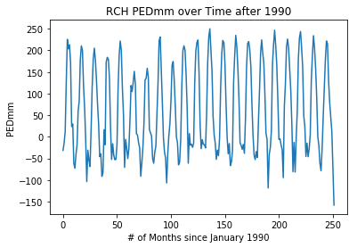

```python
plt.title("RCH PEDmm over Time after 1990")
plt.ylabel("PEDmm")
plt.xlabel("# of Months since January 1990")
plt.plot(rch_sub_join['RCH_PEDmm'])
```

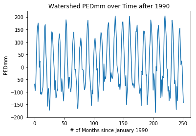

```python
plt.title("Watershed PEDmm over Time after 1990")
plt.ylabel("PEDmm")
plt.xlabel("# of Months since January 1990")
plt.plot(watershed_filtered['PED_mm'])
```

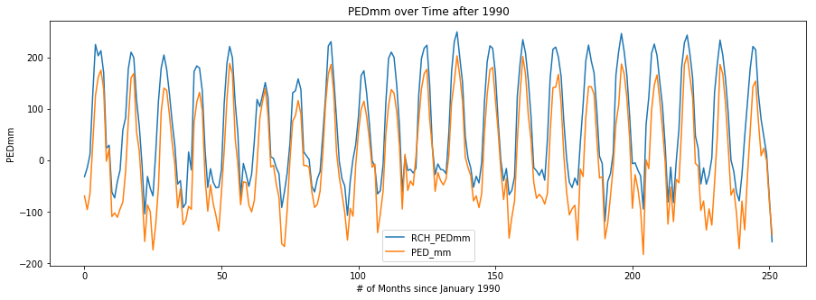

```python
plt.figure(figsize=(15,5))
plt.title("PEDmm over Time after 1990")
plt.plot(rch_sub_join['RCH_PEDmm'])
plt.plot(watershed_filtered['PED_mm'])
plt.ylabel("PEDmm")
plt.xlabel("# of Months since January 1990")
plt.legend()
```

**Analyze Results**

- In the graph above, we do see that the watershed PED fluctuates just as much as the RCH 1 PED, but at a slightly lower level.
- The peaks and valleys for both graphs happen at pretty much the same time, indicating a consistent seasonality across the river in the water cycle patterns

## Step 10: Prepare Client Deliverable

```python
print('Mean RCH PEDmm:',np.mean(rch_sub_join['RCH_PEDmm']))
print('Std Dev. RCH PEDmm:',np.std(rch_sub_join['RCH_PEDmm']))
print("*****")
print('Mean Watershed PEDmm:',np.mean(watershed_filtered['PED_mm']))
print('Std Dev. Watershed PEDmm:',np.std(watershed_filtered['PED_mm']))
```

```
Mean RCH PEDmm: 63.00002478788577
Std Dev. RCH PEDmm: 102.35313526744132
*****
Mean Watershed PEDmm: 8.649569071474529
Std Dev. Watershed PEDmm: 100.60541398944623
```

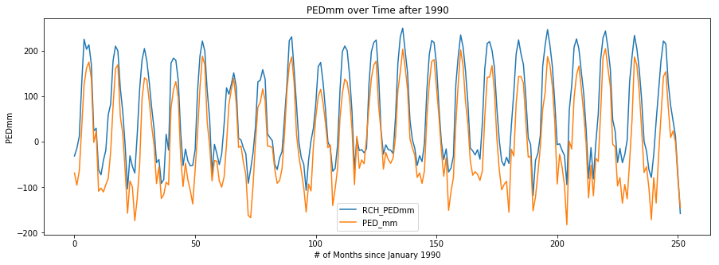

```python
plt.figure(figsize=(15,5))
plt.title("PEDmm over Time after 1990")
plt.plot(rch_sub_join['RCH_PEDmm'])
plt.plot(watershed_filtered['PED_mm'])
plt.ylabel("PEDmm")
plt.xlabel("# of Months since January 1990")
plt.legend()
```

Proposal:

- Investigate why the water cycle patterns match at both regions, but at significantly different average PED levels

## Conclusion

In this case, we learned how to:

- Query data from SQL
- Do basic data analysis
- Formulate a proposal

We focused on querying data with SQL for two reasons:

- It is the most common type of database
- Clients pretty much never allow outside people to modify the existing data, only to read it in